# flight_delays_statistical_analysis_binay

Binay Raut

2026-11-06

# Statistical Analysis

```r
library(tidyverse)
ua_final <- readRDS("../data/ua_final.rds")
```

## Departure delay and Time of Day

Is there a simple correlation between departure delays and time of day?

```r
ua_final %>%
  summarise(
    correlation = cor(hour, dep_delay)
  )
```

```
## # A tibble: 1 × 1
##   correlation
##         <dbl>
## 1       0.203
```

The correlation coefficient between scheduled departure hour and departure delay is approximately 0.203, indicating a weak positive linear relationship. This suggests that flights scheduled later in the day generally experience longer departure delays, although substantial variation exists among flights scheduled during the same hour.

During exploratory analysis, we noticed that flights leaving in the morning had less delays compared flights departing in the evening.

### Research Question:

Is there a statistically significant difference in mean departure delays between United Airlines flights scheduled in the morning (before 12 PM) and those scheduled in the evening (6 PM or later)?

Null hypothesis: Morning and evening departures have the same mean departure delay.

Alternative hypothesis: Mean departure delays differ between morning and evening flights.

Create our dataset for group comparision.

```r
time_of_day_comparison <- ua_final %>%
  mutate(
    morning_evening = case_when(
      hour >= 0 & hour < 12 ~ "Morning", # flights between midnight and 12
      hour >= 18 & hour <= 23 ~ "Evening",
      TRUE ~ NA_character_
    )
  ) %>%
  drop_na(morning_evening)
```

Review summary statistics

```r
time_summary <- time_of_day_comparison %>%
  group_by(morning_evening) %>%
  summarise(
    total_flights = n(),
    mean_delay = mean(dep_delay),
    median_delay = median(dep_delay),
    sd_delay = sd(dep_delay),
    late_pct = mean(late) * 100,
    very_late_pct = mean(very_late) * 100,
    .groups = "drop"
  )

time_summary
```

```
## # A tibble: 2 × 7
##   morning_evening total_flights mean_delay median_delay sd_delay late_pct
##   <chr>                   <int>      <dbl>        <dbl>    <dbl>    <dbl>
## 1 Evening                 11798      22.8             5     43.2     63.0
## 2 Morning                 23763       4.61           -2     25.5     33.3
## # ℹ 1 more variable: very_late_pct <dbl>
```

Evening flight experiences average delay of 22.77 minutes compared to 4.61 minutes for Morning flights. There is a difference of over 18 minutes.

Calculate observed difference in mean between evening and morning

```r
observed_diff <- mean(
  time_of_day_comparison$dep_delay[
    time_of_day_comparison$morning_evening == "Evening"
  ]
) -
  mean(
    time_of_day_comparison$dep_delay[
      time_of_day_comparison$morning_evening == "Morning"
    ]
  )

observed_diff
```

```
## [1] 18.15549
```

Simulate null distribution

```r
set.seed(5300)

N <- 5000

perm_diff <- numeric(N)

for (i in 1:N) {
  # Shuffle labels (morning and evening)
  shuffled_group <- sample(
    time_of_day_comparison$morning_evening
  )
  # Calculate the difference in group avg
  perm_diff[i] <- mean(
    time_of_day_comparison$dep_delay[
      shuffled_group == "Evening"
    ]
  ) -
    mean(
      time_of_day_comparison$dep_delay[
        shuffled_group == "Morning"
      ]
    )
}
```

Visualize permutation distribution. Expect to see a normal distribution centered around 0.

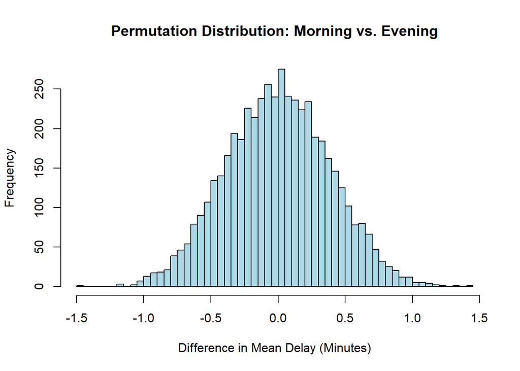

```r
hist(
  perm_diff,
  breaks = 50,
  main = "Permutation Distribution: Morning vs. Evening",
  xlab = "Difference in Mean Delay (Minutes)",
  col = "lightblue"
)
```

Calculate two-sided p-value

```r
p_value <- (
  sum(abs(perm_diff) >= abs(observed_diff)) + 1) / (length(perm_diff) + 1)

p_value
```

```
## [1] 0.00019996
```

```r
sprintf("%.5f", p_value)
```

```
## [1] "0.00020"
```

### Time of day | Findings

A two-sided permutation test was conducted to investigate whether mean departure delays differed between morning and evening United Airlines flights. The average departure delay was 4.61 minutes for morning flights and 22.77 minutes for evening flights, resulting in an observed difference of approximately 18.16 minutes. After 5000 permutations, none of the simulated differences was as extreme as the observed difference. At the 5% significance level, we reject the null hypothesis. The results provide statistical evidence that mean departure delays differ between morning and evening flights, with evening departures experiencing longer delays on average.

## Departure delay and Wind Speed

Check correlation between departure delay and wind speed

```r
ua_final %>%
  drop_na(wind_speed) %>%
  summarise(
    correlation = cor(wind_speed, dep_delay)
  )
```

```
## # A tibble: 1 × 1
##   correlation
##         <dbl>
## 1      0.0309
```

Weak positive correlation.

We previously used wind severity low, medium and high to categorize wind speed. For statistical analysis we will group wind speed at scheduled departure time into two categories: Low (Less than 10mph ), ModerateHigh (10mph and higher). We are choosing 10mph threshold so we have an approximately even distribution of flights for low and higher wind level.

### Research Question 1

Is there a statistically significant difference in the proportion of late departures (more than 0 minutes late) between flights experiencing wind speeds below 10 mph and those experiencing wind speeds of 10 mph or greater?

Null Hypothesis: The proportion of late departures is equal between low and high wind conditions.

Alternative Hypothesis: The proportion of later departures differs between low and high wind conditions.

### Research Question 2

Is there a statistically significant difference in the proportion of very late departures (more than 30 minutes late) between these two wind-speed groups?

Null Hypothesis: The proportion of very late departures is equal between low and high wind conditions.

Alternative Hypothesis: The proportion of very later departures differs between low and high wind conditions.

Create comparison dataset. Here we will save a dataset for wind comparison and filter out rows with missing wind speed observations.

```r
wind_comparison <- ua_final %>%
  drop_na(wind_speed) %>%
  mutate(
    wind_group = if_else(
      wind_speed < 10,
      "LowWind",
      "ModerateHighWind"
    )
  )

wind_comparison %>%
  count(wind_group)
```

```
## # A tibble: 2 × 2
##   wind_group           n
##   <chr>            <int>
## 1 LowWind          29080
## 2 ModerateHighWind 28589
```

Close to even distribution between high and low wind

Review summary statistics

```r
wind_summary <- wind_comparison %>%
  group_by(wind_group) %>%
  summarise(
    total_flights = n(),
    mean_delay = mean(dep_delay),
    median_delay = median(dep_delay),
    sd_delay = sd(dep_delay),
    late_pct = mean(late) * 100,
    very_late_pct = mean(very_late) * 100,
    .groups = "drop"
  )

wind_summary
```

```
## # A tibble: 2 × 7
##   wind_group       total_flights mean_delay median_delay sd_delay late_pct
##   <chr>                    <int>      <dbl>        <dbl>    <dbl>    <dbl>
## 1 LowWind                  29080       11.3            0     34.8     45.0
## 2 ModerateHighWind         28589       12.9            0     36.6     48.9
## # ℹ 1 more variable: very_late_pct <dbl>
```

The two wind-speed groups contained similar numbers of observations, with 29,080 flights experiencing wind speeds below 10 mph during departure and 28,589 flights experiencing wind speeds of 10 mph or greater. Flights experiencing higher wind speeds had a slightly longer average departure delay (12.94 minutes) than those experiencing lower wind speeds (11.26 minutes). The percentage of late departures increased from 45.04% under lower-wind conditions to 48.93% under higher-wind conditions. Similarly, the percentage of very late departures increased from 12.37% to 13.89%.

Overall, the descriptive results suggest a modest association between wind speed and departure delays. Permutation tests will be used to assess whether the differences in late and very late departure rates are statistically significant.

Capture observed differences

```r
observed_late_diff <- mean(
  wind_comparison$late[
    wind_comparison$wind_group == "ModerateHighWind"
  ]
) -
  mean(
    wind_comparison$late[
      wind_comparison$wind_group == "LowWind"
    ]
  )


observed_very_late_diff <- mean(
  wind_comparison$very_late[
    wind_comparison$wind_group == "ModerateHighWind"
  ]
) -
  mean(
    wind_comparison$very_late[
      wind_comparison$wind_group == "LowWind"
    ]
  )


observed_late_diff
```

```
## [1] 0.03886644
```

```r
observed_very_late_diff
```

```
## [1] 0.01520632
```

The observed proportion of late departures was 3.89 percentage points higher for flights experiencing wind speeds of 10 mph or greater compared with flights experiencing wind speeds below 10 mph. Similarly, the proportion of very late departures was 1.52 percentage points higher under higher-wind conditions.

Simulate null distribution for proportions of late and very late flights

```r
set.seed(5300)

N <- 5000

# Store simulated differences for each outcome
perm_late_diff <- numeric(N)
perm_very_late_diff <- numeric(N)

for (i in 1:N) {
  # Randomly shuffle labels (LowWind and ModerateHighWind)
  shuffled_group <- sample(wind_comparison$wind_group)

  # Difference in proportion of late departures
  perm_late_diff[i] <- mean(
    wind_comparison$late[
      shuffled_group == "ModerateHighWind"
    ]
  ) - mean(
    wind_comparison$late[
      shuffled_group == "LowWind"
    ]
  )

  # Difference in proportion of very late departures
  perm_very_late_diff[i] <- mean(
    wind_comparison$very_late[
      shuffled_group == "ModerateHighWind"
    ]
  ) - mean(
    wind_comparison$very_late[
      shuffled_group == "LowWind"
    ]
  )
}
```

Calculate P-values

```r
p_late <- (sum(abs(perm_late_diff) >= abs(observed_late_diff)) + 1) / (N + 1)

p_very_late <- (sum(abs(perm_very_late_diff) >= abs(observed_very_late_diff)) + 1) / (N + 1)

# Display results

sprintf("%.5f", p_late)
```

```
## [1] "0.00020"
```

```r
sprintf("%.5f", p_very_late)
```

```
## [1] "0.00020"
```

Check if there were any simulated difference as extreme than the observed diff.

```r
sum(abs(perm_late_diff) >= abs(observed_late_diff))
```

```
## [1] 0
```

```r
sum(abs(perm_very_late_diff) >= abs(observed_very_late_diff))
```

```
## [1] 0
```

None of the simulated differences were as extreme as the observed difference.

### Wind Speed | Findings

Two-sided permutation tests were conducted to investigate differences in late and very late departure rates between flights experiencing wind speeds below 10 mph and those experiencing wind speeds of 10 mph or greater. The proportion of late departures was 3.89 percentage points higher under higher-wind conditions, while the proportion of very late departures was 1.52 percentage points higher. After 5000 permutations, neither test produced a simulated difference as extreme as its observed difference. The estimated p-value was approximately 0.0002 for both tests. At the 5% significance level, we reject both null hypotheses. The results provide statistical evidence of differences in late and very late departure proportions between the two wind-speed groups.

## Departure Delay and Precipitation

```r
ua_final %>%
  drop_na(precip) %>%
  summarise(
    correlation = cor(precip, dep_delay)
  )
```

```
## # A tibble: 1 × 1
##   correlation
##         <dbl>
## 1      0.0821
```

There is a weak correlation between precipitation and departure delays.

```r
precip_test <- ua_final %>%
  drop_na(precip) %>%
  mutate(wet_dry = if_else(precip > 0, "Wet", "Dry"))

precip_test %>%
  group_by(wet_dry) %>%
  summarise(
    n = n(),
    late_rate = mean(late),
    very_late_rate = mean(very_late),
    .groups = "drop"
  )
```

```
## # A tibble: 2 × 4
##   wet_dry     n late_rate very_late_rate
##   <chr>   <int>     <dbl>          <dbl>
## 1 Dry     53645     0.457          0.122
## 2 Wet      4041     0.634          0.248
```

During exploratory analysis we found that the percentage of flight late and very late was higher when there was percipitaiton (wet conditions) versus when there was no precipitation (dry conditions).

### Research Question 1

Is there a statistically significant difference in the proportion of late departures (more than 0 minutes late) between flights experiencing precipitation (wet conditions) and those experiencing dry condition?

Null Hypothesis: The proportion of late departures is equal between dry (where there is no precipitation) and wet conditions (where there is any precipitation).

Alternative Hypothesis: The proportion of late departures differs between dry and wet conditions.

### Research Question 2

Is there a statistically significant difference in the proportion of very late departures (more than 30 minutes late) between flights experiencing precipitation (wet conditions) and those experiencing dry condition?

Null Hypothesis: The proportion of very late departures is equal between dry (where there is no precipitation) and wet conditions (where there is any precipitation).

Alternative Hypothesis: The proportion of very late departures differs between dry and wet conditions.

```r
observed_precip_late_diff <- mean(
  precip_test$late[
    precip_test$wet_dry == "Wet"
  ]
) -
  mean(
    precip_test$late[
      precip_test$wet_dry == "Dry"
    ]
  )


observed_precip_very_late_diff <- mean(
  precip_test$very_late[
    precip_test$wet_dry == "Wet"
  ]
) -
  mean(
    precip_test$very_late[
      precip_test$wet_dry == "Dry"
    ]
  )


observed_precip_late_diff
```

```
## [1] 0.1770022
```

```r
observed_precip_very_late_diff
```

```
## [1] 0.1255425
```

The observed proportion of late departures was 17.70 percentage points higher for flights experiencing wet conditions compared with flights departing during dry. Similarly, the proportion of very late departures was 12.55 percentage points higher under wet conditions.

Simulate null distribution of late vs very late flights during wet and dry conditions.

```r
set.seed(5300)

N <- 5000

# Store simulated differences for each outcome
perm_precip_late_diff <- numeric(N)
perm_precip_very_late_diff <- numeric(N)

for (i in 1:N) {
  # Randomly shuffle Wet-Dry labels
  shuffled_group <- sample(precip_test$wet_dry)

  # Difference in proportion of late departures
  perm_precip_late_diff[i] <- mean(
    precip_test$late[
      shuffled_group == "Wet"
    ]
  ) - mean(
    precip_test$late[
      shuffled_group == "Dry"
    ]
  )

  # Difference in proportion of very late departures
  perm_precip_very_late_diff[i] <- mean(
    precip_test$very_late[
      shuffled_group == "Wet"
    ]
  ) - mean(
    precip_test$very_late[
      shuffled_group == "Dry"
    ]
  )
}
```

Calculate p-value

```r
p_precip_late <- (sum(abs(perm_precip_late_diff) >= abs(observed_precip_late_diff)) + 1) / (N + 1)

p_precip_very_late <- (sum(abs(perm_precip_very_late_diff) >= abs(observed_precip_very_late_diff)) + 1) / (N + 1)

# Display results

sprintf("%.5f", p_precip_late)
```

```
## [1] "0.00020"
```

```r
sprintf("%.5f", p_precip_very_late)
```

```
## [1] "0.00020"
```

### Precipitation | Findings

Two-sided permutation tests were conducted using 5000 permutations to investigate whether the proportions of late and very late departures differed between wet and dry conditions. The observed proportion of late departures was 17.70 percentage points higher during wet conditions, while the proportion of very late departures was 12.55 percentage points higher. Both tests produced estimated p-values of approximately 0.0002. At the 5% significance level, we reject both null hypotheses. The results provide strong statistical evidence that late and very late departure rates differ between wet and dry conditions, with higher observed rates during wet conditions.

Bootstrap simulation of the difference in late proportions

```r
# Separate late-departure outcomes by precipitation group
wet_late <- precip_test$late[
  precip_test$wet_dry == "Wet"
]

dry_late <- precip_test$late[
  precip_test$wet_dry == "Dry"
]

# Observed difference (Wet - Dry)
observed_diff <- mean(wet_late) - mean(dry_late)

# Bootstrap simulation
set.seed(5300)
B <- 5000

boot_diff <- numeric(B)

for (i in 1:B) {
  boot_wet <- sample(wet_late, replace = TRUE)
  boot_dry <- sample(dry_late, replace = TRUE)

  boot_diff[i] <- mean(boot_wet) - mean(boot_dry)
}
```

```r
# 95% percentile bootstrap confidence interval
boot_ci <- quantile(
  boot_diff,
  probs = c(0.025, 0.975)
)

data.frame(
  Observed_Difference = observed_diff * 100,
  CI_Lower = boot_ci[1] * 100,
  CI_Upper = boot_ci[2] * 100
)
```

```
##      Observed_Difference CI_Lower CI_Upper
## 2.5%            17.70022 16.15524 19.21759
```

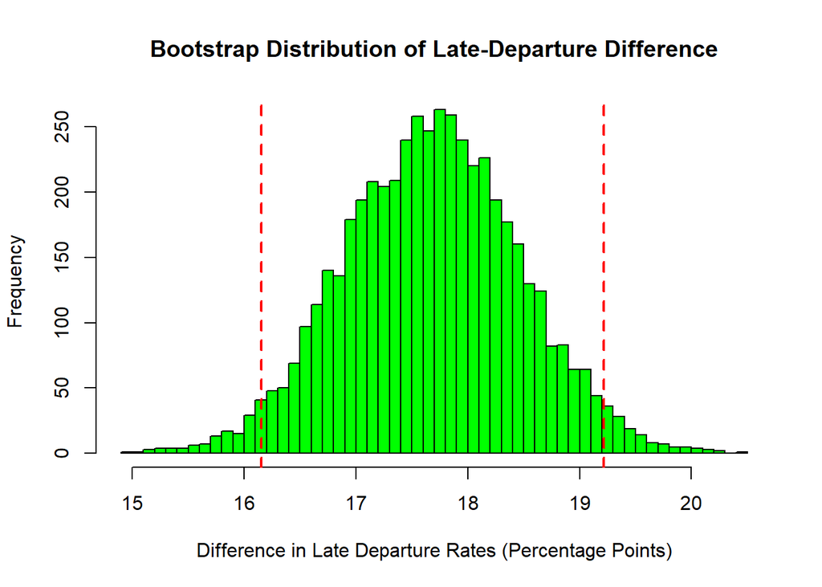

```r
hist(
  boot_diff * 100,
  breaks = 40,
  main = "Bootstrap Distribution of Late-Departure Difference",
  xlab = "Difference in Late Departure Rates (Percentage Points)",
  col = "green",
)

abline(
  v = boot_ci * 100,
  col = "red",
  lty = 2,
  lwd = 2
)
```

## Departure Delay and Time of Year

During exploratory data analysis, we observed that departure delays varied across months, with particularly high delay rates during June, July, and December. To investigate seasonal differences, group flights into summer (June–August) and winter (December–February) categories.

### Research Question 1

Is there a statistically significant difference in the proportion of late departures (more than 0 minutes late) between flights in summer months (June-August) and winter months (December-February?

Null Hypothesis:The proportion of late departures is equal between summer and winter.

Alternative Hypothesis: The proportion of late departures differs between summer and winter.

### Research Question 2

Is there a statistically significant difference in the proportion of very late departures (more than 30 minutes late) between flights in summer months (June-August) and winter months (December-February?

Null Hypothesis:The proportion of very late departures is equal between summer and winter.

Alternative Hypothesis: The proportion of very late departures differs between summer and winter.

Create our dataset of analysis

```r
time_of_year_comparison <- ua_final %>%
  mutate(
    summer_winter = case_when(
      month %in% c(6, 7, 8) ~ "Summer", # Assign Summer label if month is 6,7,8
      month %in% c(12, 1, 2) ~ "Winter", # Assign Winter label if month is 12,1,2
      TRUE ~ NA_character_ # Since there are other months, we assign "NA"
    )
  ) %>%
  drop_na(summer_winter) # Filter out observation for other than summer or winter
```

Capture observed values

```r
observed_season_late_diff <- mean(
  time_of_year_comparison$late[
    time_of_year_comparison$summer_winter == "Summer"
  ]
) -
  mean(
    time_of_year_comparison$late[
      time_of_year_comparison$summer_winter == "Winter"
    ]
  )

observed_season_very_late_diff <- mean(
  time_of_year_comparison$very_late[
    time_of_year_comparison$summer_winter == "Summer"
  ]
) -
  mean(
    time_of_year_comparison$very_late[
      time_of_year_comparison$summer_winter == "Winter"
    ]
  )

observed_season_late_diff
```

```
## [1] 0.02476267
```

```r
observed_season_very_late_diff
```

```
## [1] 0.05036856
```

Simulate null distribution

```r
set.seed(5300)

N <- 5000

perm_season_late_diff <- numeric(N)
perm_season_very_late_diff <- numeric(N)

for (i in 1:N) {
  # Shuffle summer/winter labels
  shuffled_group <- sample(time_of_year_comparison$summer_winter)

  # Difference in late proportions
  perm_season_late_diff[i] <- mean(time_of_year_comparison$late[shuffled_group == "Summer"]) -
    mean(time_of_year_comparison$late[shuffled_group == "Winter"])

  # Difference in very late proportions
  perm_season_very_late_diff[i] <- mean(time_of_year_comparison$very_late[shuffled_group == "Summer"]) -
    mean(time_of_year_comparison$very_late[shuffled_group == "Winter"])
}
```

Calculate p-value

```r
p_season_late <- (
  sum(abs(perm_season_late_diff) >=
    abs(observed_season_late_diff)) + 1
) / (N + 1)

p_season_very_late <- (
  sum(abs(perm_season_very_late_diff) >=
    abs(observed_season_very_late_diff)) + 1
) / (N + 1)

sprintf("%.5f", p_season_late)
```

```
## [1] "0.00020"
```

```r
sprintf("%.5f", p_season_very_late)
```

```
## [1] "0.00020"
```

### Time of year | Findings

Two-sided permutation tests were conducted using 5000 permutations to investigate if the proportions of late and very late departures differed between summer months and winter months. The observed proportion of late departures was 2.48 percentage points higher during summer compared with winter. Similarly, the proportion of very late departures was 5.04 percentage points higher during summer. Both permutation tests produced estimated p-values of approximately 0.0002. At the 5% significance level, we reject both null hypotheses. The results provide statistical evidence that the proportions of late and very late departures differ between summer and winter, with higher observed rates during summer.

## Departure Delay and Temperature

Exploratory analysis suggest an association between higher temperatures and increased departure delays.

### Research Question 1

Is there a statistically significant difference in the proportion of late departures between hot and moderate temperature conditions?

Null Hypothesis: The proportion of late departures is equal between hot and moderate conditions.

Alternative Hypothesis: The proportions differ between the two conditions.

### Research Question 2

Is there a statistically significant difference in the proportion of very late departures (more than 30 minutes late) between hot and moderate conditions?

Null Hypothesis: The proportion of very late departures is equal between hot and moderate conditions.

Alternative Hypothesis: The proportions differ between the two conditions.

```r
temp_test <- ua_final %>%
  drop_na(temp) %>%
  mutate(
    temp_category = case_when(
      temp < 40 ~ "Cold",
      temp < 80 ~ "Moderate",
      TRUE ~ "Hot"
    )
  ) %>%
  filter(temp_category %in% c("Moderate", "Hot"))
```

Calculate observed differences

```r
# Difference in late departure proportions
observed_temp_late_diff <- mean(temp_test$late[temp_test$temp_category == "Hot"]) -
  mean(
    temp_test$late[temp_test$temp_category == "Moderate"]
  )

# Difference in very late departure proportions
observed_temp_very_late_diff <- mean(
  temp_test$very_late[temp_test$temp_category == "Hot"]
) -
  mean(temp_test$very_late[temp_test$temp_category == "Moderate"])

observed_temp_late_diff
```

```
## [1] 0.129309
```

```r
observed_temp_very_late_diff
```

```
## [1] 0.06636766
```

- Late departure difference of approximately 12.93%.
- Very late departure difference of approximately 6.64%.

Perform Permutation test

```r
set.seed(5300)

N <- 5000

perm_temp_late_diff <- numeric(N)
perm_temp_very_late_diff <- numeric(N)

for (i in 1:N) {
  # Shuffle temperature labels
  shuffled_group <- sample(temp_test$temp_category)

  # Late departure difference
  perm_temp_late_diff[i] <- mean(
    temp_test$late[shuffled_group == "Hot"]
  ) -
    mean(
      temp_test$late[shuffled_group == "Moderate"]
    )

  # Very late departure difference
  perm_temp_very_late_diff[i] <- mean(
    temp_test$very_late[shuffled_group == "Hot"]
  ) -
    mean(
      temp_test$very_late[shuffled_group == "Moderate"]
    )
}
```

```r
p_temp_late <- (
  sum(abs(perm_temp_late_diff) >=
    abs(observed_temp_late_diff)) + 1
) / (N + 1)

p_temp_very_late <- (
  sum(abs(perm_temp_very_late_diff) >=
    abs(observed_temp_very_late_diff)) + 1
) / (N + 1)

sprintf("%.5f", p_temp_late)
```

```
## [1] "0.00020"
```

```r
sprintf("%.5f", p_temp_very_late)
```

```
## [1] "0.00020"
```

### Temperature | Findings

Two-sided permutation tests were conducted using 5000 permutations to compare late and very late departure rates between hot conditions (80°F or higher) and moderate conditions (40°F to below 80°F). Flights departing under hot conditions had a late-departure rate approximately 12.93 percentage points higher than flights departing under moderate conditions. Similarly, the proportion of very late departures was 6.64 percentage points higher during hot conditions. Both tests produced estimated p-values of approximately 0.0002. At the 5% significance level, we reject both null hypotheses. These results provide statistical evidence of differences in late and very late departure rates between the two temperature categories under the permutation-test assumptions.

## Departure Delay and Visibility

Exploratory analysis showed that departure delays varied between normal and reduced visibility conditions.

### Research Question 1

Is there a statistically significant difference in the proportion of late departures between flights experiencing reduced visibility and those experiencing normal visibility?

Null Hypothesis: The proportion of late departures is equal between reduced and normal visibility conditions.

Alternative Hypothesis: The proportion of late departures differs between reduced and normal visibility conditions.

### Research Question 2

Is there a statistically significant difference in the proportion of very late departures between flights experiencing reduced visibility and those experiencing normal visibility?

Null Hypothesis: The proportion of very late departures is equal between reduced and normal visibility conditions.

Alternative Hypothesis: The proportion of very late departures differs between reduced and normal visibility conditions.

Create dataset for analysis

```r
visibility_test <- ua_final %>%
  drop_na(visib) %>%
  mutate(
    visibility_category = case_when(
      visib < 10 ~ "Reduced",
      TRUE ~ "Normal"
    )
  )
```

Calculate observed differences

```r
# Difference in late departure proportions
observed_visib_late_diff <- mean(
  visibility_test$late[
    visibility_test$visibility_category == "Reduced"
  ]
) -
  mean(
    visibility_test$late[
      visibility_test$visibility_category == "Normal"
    ]
  )

# Difference in very late departure proportions
observed_visib_very_late_diff <- mean(
  visibility_test$very_late[
    visibility_test$visibility_category == "Reduced"
  ]
) -
  mean(
    visibility_test$very_late[
      visibility_test$visibility_category == "Normal"
    ]
  )

observed_visib_late_diff
```

```
## [1] 0.05230128
```

```r
observed_visib_very_late_diff
```

```
## [1] 0.05242332
```

```r
set.seed(5300)

N <- 5000

perm_visib_late_diff <- numeric(N)
perm_visib_very_late_diff <- numeric(N)

for (i in 1:N) {
  # Shuffle visibility group labels
  shuffled_group <- sample(
    visibility_test$visibility_category
  )

  # Difference in late departure proportions
  perm_visib_late_diff[i] <- mean(
    visibility_test$late[
      shuffled_group == "Reduced"
    ]
  ) -
    mean(
      visibility_test$late[
        shuffled_group == "Normal"
      ]
    )

  # Difference in very late departure proportions
  perm_visib_very_late_diff[i] <- mean(
    visibility_test$very_late[
      shuffled_group == "Reduced"
    ]
  ) -
    mean(
      visibility_test$very_late[
        shuffled_group == "Normal"
      ]
    )
}
```

```r
p_visib_late <- (
  sum(abs(perm_visib_late_diff) >=
    abs(observed_visib_late_diff)) + 1
) / (N + 1)

p_visib_very_late <- (
  sum(abs(perm_visib_very_late_diff) >=
    abs(observed_visib_very_late_diff)) + 1
) / (N + 1)

sprintf("%.5f", p_visib_late)
```

```
## [1] "0.00020"
```

```r
sprintf("%.5f", p_visib_very_late)
```

```
## [1] "0.00020"
```

### Visibility | Findings

Two-sided permutation tests using 5000 permutations were conducted to examine whether late and very late departure rates differed between flights experiencing reduced visibility (below 10 miles) and normal recorded visibility (10 miles). Flights experiencing reduced visibility had a late-departure rate 5.23 percentage points higher than flights under normal visibility conditions. Similarly, very late departures were 5.24 percentage points more frequent under reduced visibility. Both permutation tests produced estimated p-values of approximately 0.0002. At the 5% significance level, we reject both null hypotheses. The results indicate statistically significant differences in late and very late departure rates between the two visibility groups under the permutation-test assumptions.